# Body Temperature - T-Test

Lucas Andrade

2024-06-29

## Exercicio 1

O artigo A Critical Appraisal of 98.6 Degrees F, the Upper Limit of the Normal Body Temperature, and Other Legacies of Carl Reinhold August Wunderlich? questiona a nocao de que a verdadeira temperatura corporal media eh 98,6. Alem disso ha tambem alguma duvida sobre se as temperaturas corporais medias para as mulheres sao iguais as dos homens (nivel de significancia de 0,01).

Os dados sao NormTemp.sas7bdat e o dicionario de dados:

- ID - Identificador do individuo
- BodyTemp - Temperatura corporal (graus Fahrenheit)
- Gender - Sexo do individuo
- HeartRate - Frequencia cardiaca (batimentos por minuto)

Referencia: https://jamanetwork.com/journals/jama/article-abstract/400116

### Import Data

As the dataset is a .sas file I’m using haven package to import it

### Exploring Data

```r
summary(temp)
```

```
##        ID            BodyTemp         Gender            HeartRate
##  Min.   :  1.00   Min.   : 96.30   Length:130         Min.   :57.00
##  1st Qu.: 33.25   1st Qu.: 97.80   Class :character   1st Qu.:69.00
##  Median : 65.50   Median : 98.30   Mode  :character   Median :74.00
##  Mean   : 65.50   Mean   : 98.25                      Mean   :73.76
##  3rd Qu.: 97.75   3rd Qu.: 98.70                      3rd Qu.:79.00
##  Max.   :130.00   Max.   :100.80                      Max.   :89.00
```

BodyTemp distribution

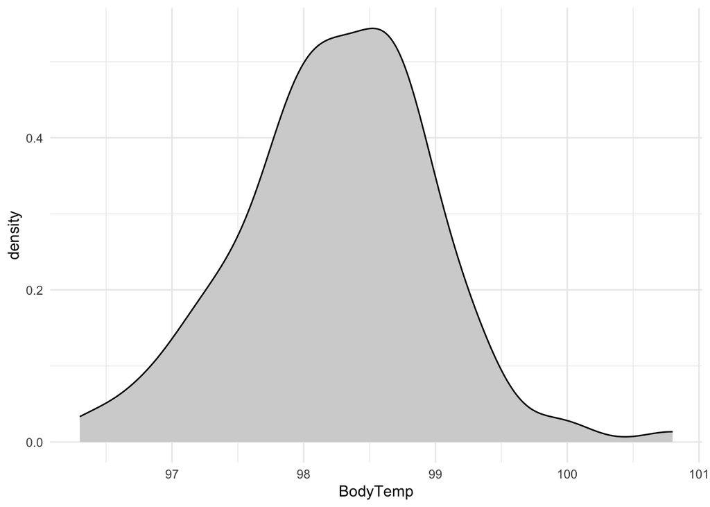

```r
temp %>%
  ggplot(aes(x=BodyTemp))+
  geom_density(fill = 'lightgray')+
  theme_minimal()
```

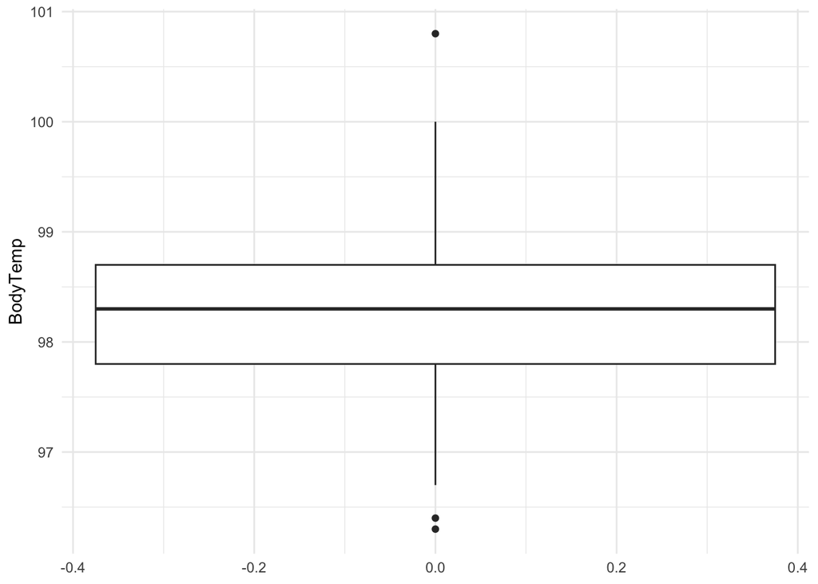

```r
temp %>%
  ggplot(aes(y= BodyTemp))+
  geom_boxplot()+
  theme_minimal()
```

BodyTemp average by gender

```r
 temp %>%
  dplyr::group_by(Gender) %>%
  dplyr::summarise(avg = round(mean(BodyTemp, na.rm = TRUE),2))
```

```
## # A tibble: 2 × 2
##   Gender   avg
##   <chr>  <dbl>
## 1 Female  98.4
## 2 Male    98.1
```

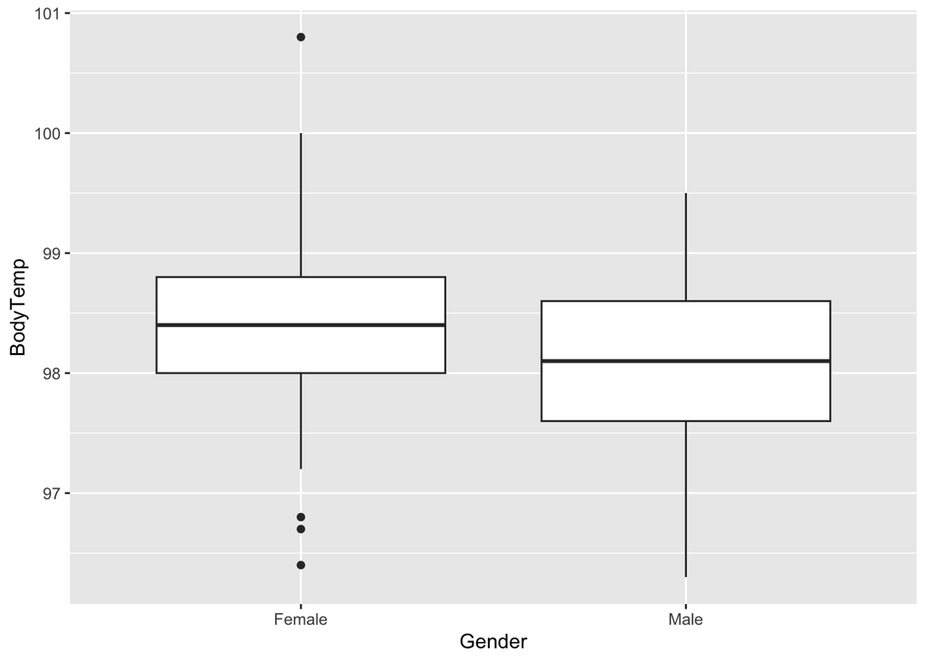

```r
temp %>%
  ggplot(aes(x = Gender, y=BodyTemp))+
  geom_boxplot()
```

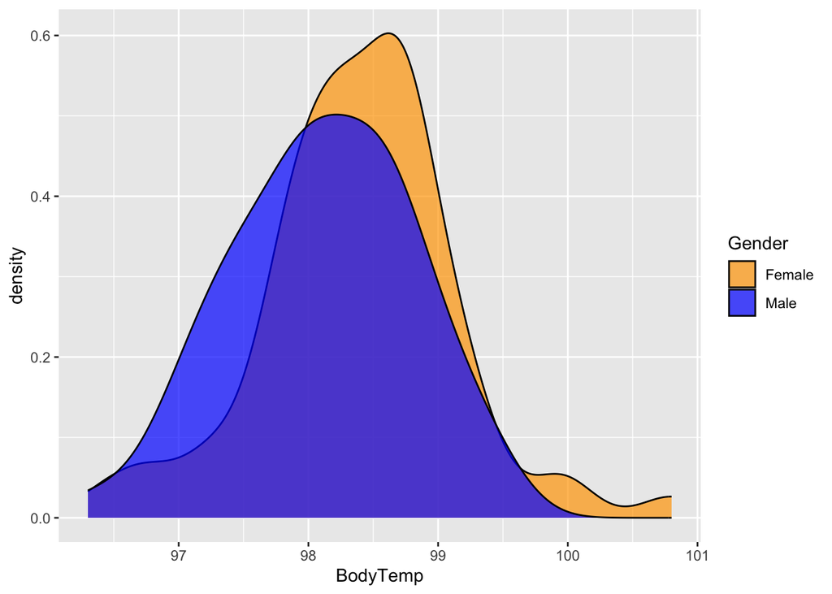

```r
temp %>%
ggplot(aes(x=BodyTemp, fill=Gender))+
  geom_density(alpha = 0.7)+
  scale_fill_manual(values = c('orange', 'blue'))
```

### Testing

1. ‘questiona a nocao de que a verdadeira temperatura corporal media eh 98,6.’

#### Verificando a normalidade da amostra.

Como a pergunta a ser respondida tem como metrica de comparacao um valor constante, 98,6. Faremos a verificacao da normalidade da propria variavel temperatura

Para o teste de normalidade considerei duas opçoes: o teste KS e o teste de Shapiro Wilks O teste Ks só pode ser utilizado quando o tamanho da amaostra é maior que 30 (n > 30). Já o teste de Shapiro Wilks é condicionado a amostras de n >= 4 e n =< 2000. Na exploracao do dataset vimos que n = 130, e por minha escolha utilizarei o teste KS para verificara a normalidade da amostra.

```r
ks.test(temp$BodyTemp,
        'pnorm',
        mean(temp$BodyTemp),
        sd(temp$BodyTemp))
```

```
##
##  Asymptotic one-sample Kolmogorov-Smirnov test
##
## data:  temp$BodyTemp
## D = 0.064727, p-value = 0.6474
## alternative hypothesis: two-sided
```

O teste KS usa sempre H0 como normal e um nivel de confianca de 95%. De acordo com o resultado do teste p-value = 0.6474, portanto a distribuicao da variavel temperatura corporal pode ser encarada como uma normal.

#### T test

Coma. normalidade já atestada, podemos fazer o teste para verificar a validade da afirmacao de que a temperatura corporal é em média 98.6

H0: mu = 98.6 H1: mu <> 98.6

```r
t.test(temp$BodyTemp,
       mu = 98.6)
```

```
##
##  One Sample t-test
##
## data:  temp$BodyTemp
## t = -5.4548, df = 129, p-value = 2.411e-07
## alternative hypothesis: true mean is not equal to 98.6
## 95 percent confidence interval:
##  98.12200 98.37646
## sample estimates:
## mean of x
##  98.24923
```

De acordo com os resultados do teste (p-value = 2.411e-07) a hipotese nula (H0 = 98.6) foi rejeitada e podemos afirmar que a mostra nao preovem de uma populacao com média de temperatura corporal igual a 98.6.

2. Alem disso ha tambem alguma duvida sobre se as temperaturas corporais medias para as mulheres sao iguais as dos homens

#### Verificando a normalidade das amostras de temperatura de mulheres e homens

Também utilizaeri o teste KS para verificar a normalidade de ambas as amostras

```r
female_temp <- temp %>%
  dplyr::filter(Gender == 'Female')

ks.test(female_temp$BodyTemp,
        'pnorm',
        mean(female_temp$BodyTemp),
        sd(female_temp$BodyTemp))
```

```
##
##  Asymptotic one-sample Kolmogorov-Smirnov test
##
## data:  female_temp$BodyTemp
## D = 0.10782, p-value = 0.4365
## alternative hypothesis: two-sided
```

De acordo com os resultados do teste é possivel afirmar que a amostra de temperatura corporal feminina segue uma distribuicao normal

```r
male_temp <- temp %>%
  dplyr::filter(Gender == 'Male')

ks.test(male_temp$BodyTemp,
        'pnorm',
        mean(male_temp$BodyTemp),
        sd(male_temp$BodyTemp))
```

```
##
##  Asymptotic one-sample Kolmogorov-Smirnov test
##
## data:  male_temp$BodyTemp
## D = 0.068515, p-value = 0.9204
## alternative hypothesis: two-sided
```

De acordo com os resultados do teste é possivel afirmar que a amostra de temperatura corporal masculina tambem segue uma distribuicao normal.

#### Verificando homogeneidade de variancia entre as amostras

Um teste parametrico comparativo de duas amostras exige que as variancias sejam homogeneas.

```r
leveneTest(BodyTemp ~ Gender,
            data = temp)
```

```
## Levene's Test for Homogeneity of Variance (center = median)
##        Df F value Pr(>F)
## group   1  0.0635 0.8014
##       128
```

O resultado do teste de Levene indica que as amostras possuem variancias homogeneas, sendo assim podemos aplicar o teste t para duas amostras

#### T - Test

Existem duas possibilidades para aplicacao de teste T para comparar médias de amostras distintas. A escolha do teste ideal é baseada na relacao de dependencia das amostras. No caso em questao as amostras são independentes.

A pergunta que nos move questiona se a temperatura corporal de homens e mulheres é igual, portanto as hipoteses formuladas serao:

H0: m_mulheres = m_homens H1: m_mulheres <> m_homens

```r
t.test(BodyTemp ~ Gender,
       data = temp,
       var.equal = TRUE)
```

```
##
##  Two Sample t-test
##
## data:  BodyTemp by Gender
## t = 2.2854, df = 128, p-value = 0.02393
## alternative hypothesis: true difference in means between group Female and group Male is not equal to 0
## 95 percent confidence interval:
##  0.03882216 0.53963938
## sample estimates:
## mean in group Female   mean in group Male
##             98.39385             98.10462
```

Considerando os resultados do teste e um nivel de confianca igual a 99% nao é possivel rejeitar a hipotese de que a temperatura corporal de homens e mulheres seja igual